# STAT 9100 HOMEWORK 4

Peng Shao

March 13, 2016

## 1

### a.

Firstly, I tried two candidates for each parameter to explore how the values of parameters affect the model. The comparisons of performances are shown as below, where n is the number of hidden units, eta is learning rate and niter is the number of iterations.

| batch_size | n | eta | niter | mse | time |
| --- | --- | --- | --- | --- | --- |
| 1000 | 100 | 0.001 | 200 | 82.72997 | 25.0333816329638 mins |
| 500 | 100 | 0.001 | 200 | 81.86168 | 15.0094160517057 mins |
| 1000 | 50 | 0.001 | 200 | 95.27384 | 25.9833889007568 mins |
| 500 | 50 | 0.001 | 200 | 95.29577 | 14.5915921171506 mins |
| 1000 | 100 | 0.010 | 200 | 51.97142 | 24.1317209005356 mins |
| 500 | 100 | 0.010 | 200 | 52.22719 | 11.1662522514661 mins |
| 1000 | 50 | 0.010 | 200 | 60.37581 | 21.4933004339536 mins |
| 500 | 50 | 0.010 | 200 | 60.00229 | 9.93551119963328 mins |
| 1000 | 100 | 0.001 | 100 | 99.09260 | 12.4043050169945 mins |
| 500 | 100 | 0.001 | 100 | 100.88258 | 5.58180388212204 mins |
| 1000 | 50 | 0.001 | 100 | 129.29261 | 10.5478509346644 mins |
| 500 | 50 | 0.001 | 100 | 124.47313 | 4.98161446650823 mins |
| 1000 | 100 | 0.010 | 100 | 59.19046 | 12.3960566163063 mins |
| 500 | 100 | 0.010 | 100 | 59.09987 | 5.60734366575877 mins |
| 1000 | 50 | 0.010 | 100 | 71.91141 | 10.4691515167554 mins |
| 500 | 50 | 0.010 | 100 | 70.86252 | 4.99019093513489 mins |

We can see that the learning rate has the most important effect and larger learning rate will lead the smaller mse and shorter runtime. So I try to increase the learning rate, and when the learning rate is larger than 0.5, there is no significant difference any more. Then I change the other three parameters and find that increasing these parameters does not greatly reduce the mse but will cost much more time. Hence the parameters of the final model I choose are: `batch_size=50`, `n=20`, `eta = 0.5` and `niter = 200`. The final MSE is about 41 on average and the program only takes 55 seconds.

### b.

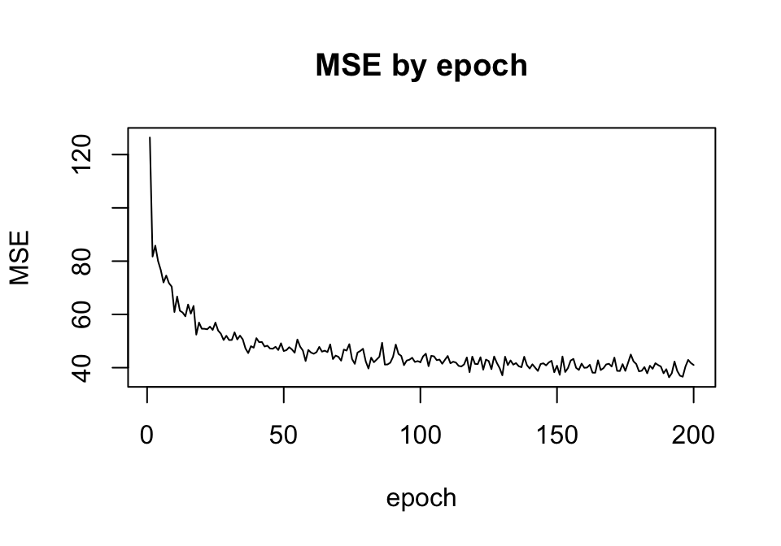

From the figure we can see that the algorithm converges very fast at the beginning and the MSE becomes small enough after about 50 iterations. Then more iterations does not improve the result so much.

### c.

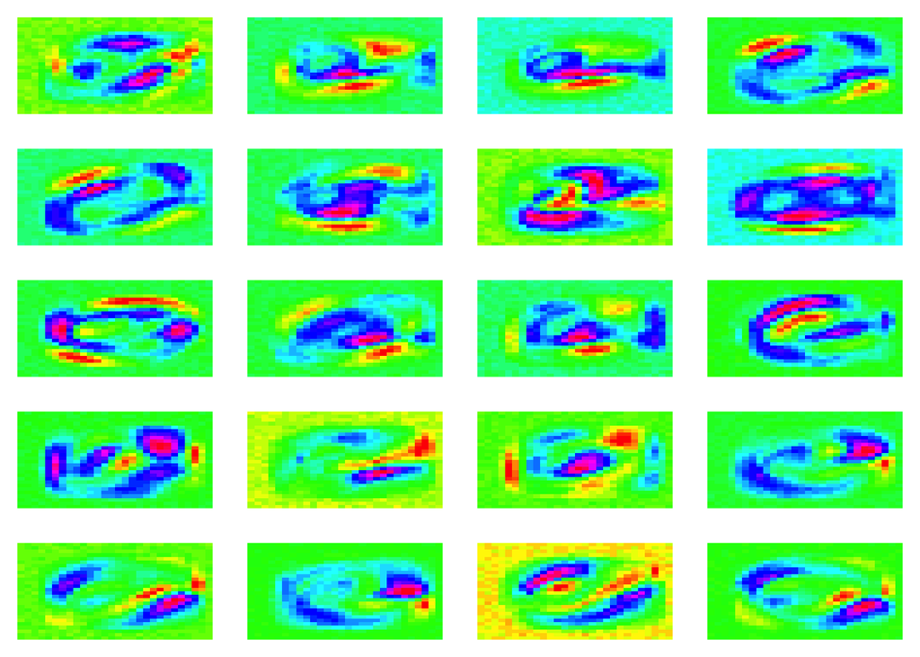

### d.

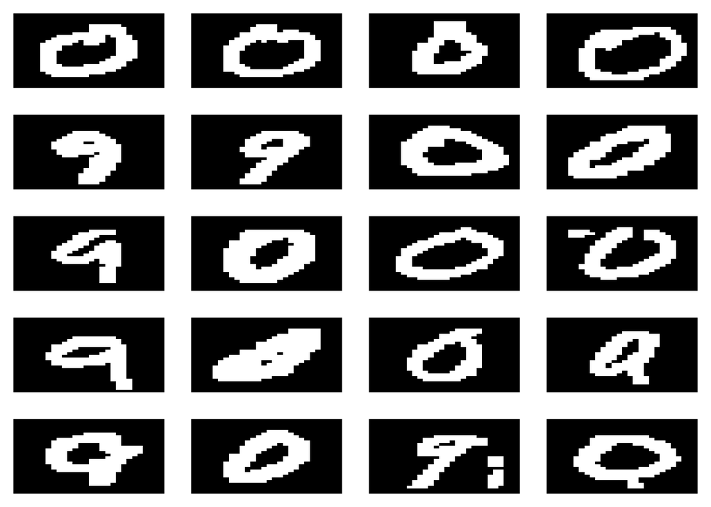

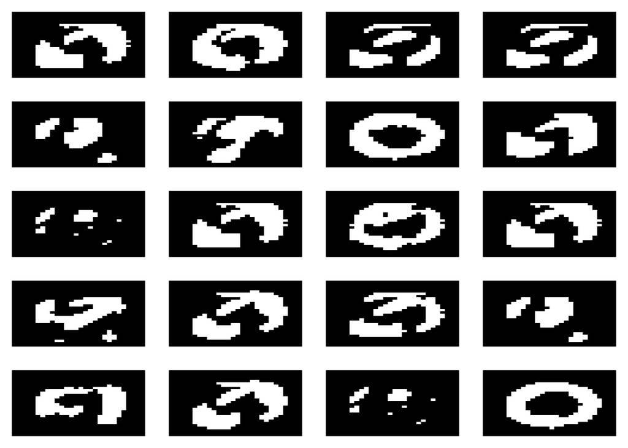